# assigmnent

2026-05-10

Load necessary Libraries

```r
suppressPackageStartupMessages({
  library(GenomicRanges)
  library(epiwraps)
  library(ggplot2)
  library(rGREAT)
})
```

Download File

```r
options(timeout = 6000)
download.file("https://ethz-ins.org/content/clustering_assignment.zip", "assignment_data.zip")
unzip("assignment_data.zip")
list.files()
```

```
##  [1] "~$terpretation of results.docx" "assignment_data.zip"
##  [3] "assignment_files"               "assignment_trial.Rmd"
##  [5] "assignment.html"                "assignment.Rmd"
##  [7] "clustering_practical.zip"       "Creb1.bed"
##  [9] "Creb1.bw"                       "Creb3.bed"
## [11] "Creb3.bw"                       "Creb3L1.bed"
## [13] "Creb3L1.bw"                     "H3K27ac.bw"
## [15] "H3K4me3.bw"                     "Interpretation of results.docx"
## [17] "MAFK.bw"                        "p300.bw"
## [19] "practical_week09.Rmd"           "regions.bed"
## [21] "slides_w9.pdf"
```

Filter for high-confidence peaks

```r
tracks <- list.files(pattern="bw$")
peaks <- list.files(pattern="bed$")
peaks <- lapply(peaks, rtracklayer::import.bed)
peaks <- lapply(peaks, FUN=function(x) x[x$score>800])
regions <- reduce(unlist(GRangesList(peaks)))
```

Creating heatmaps for data overview

```r
ese_4 <- signal2Matrix(tracks, regions, extend=2000)
```

```
## Reading Creb1.bw
```

```
## Reading Creb3.bw
```

```
## Reading Creb3L1.bw
```

```
## Reading H3K27ac.bw
```

```
## Reading H3K4me3.bw
```

```
## Reading MAFK.bw
```

```
## Reading p300.bw
```

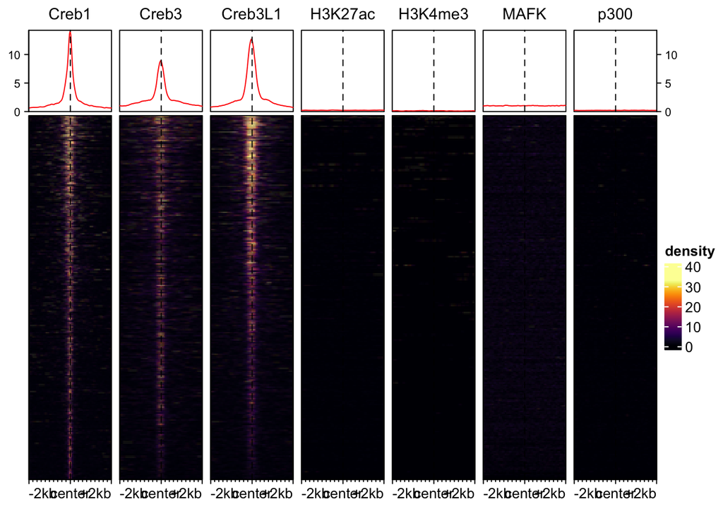

```r
plotEnrichedHeatmaps(ese_4)
```

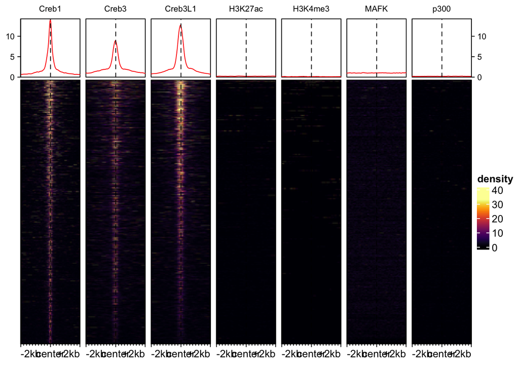

```r
ese2 <- ese_4[1:1000,]
plotEnrichedHeatmaps(ese_4, column_title_gp = gpar(fontsize = 8))
```

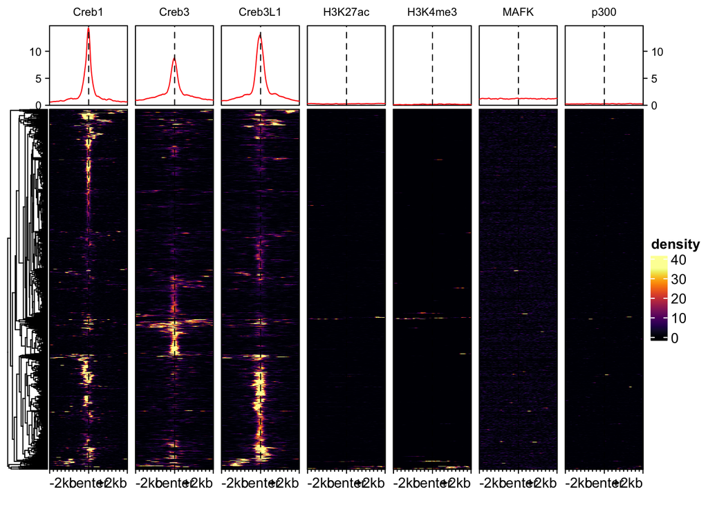

```r
plotEnrichedHeatmaps(ese2, cluster_rows = TRUE, show_row_dend = TRUE,
                     column_title_gp = gpar(fontsize = 8))
```

Figure 1

## Clustering

```r
set.seed(123)  # to ensure that it gives the same results everytime
cl_4 <- clusterSignalMatrices(ese_4, k=4)
```

```
##   ~65% of the variance explained by clusters
```

```r
table(cl_4)
```

```
## cl_4
##   1   2   3   4
## 911 197 447 714
```

```r
head(cl_4)
```

```
## [1] 4 1 1 1 1 1
## Levels: 1 2 3 4
```

```r
length(cl_4)
```

```
## [1] 2269
```

```r
nrow(ese_4)
```

```
## [1] 2269
```

```r
# to make sure the cluster labels stay associated with the corresponding regions/rows
# even if we manipulate the object, put them inside the rowData of the object:
rowData(ese_4)$cluster <- cl_4
head(rowData(ese_4))
```

```
## DataFrame with 6 rows and 1 column
##                     cluster
##                    <factor>
## chr1:778487-779069        4
## chr1:904436-904985        1
## chr1:941785-942096        1
## chr1:943126-943501        1
## chr1:959088-959463        1
## chr1:961148-961904        1
```

Plotting the clusters with k=4:

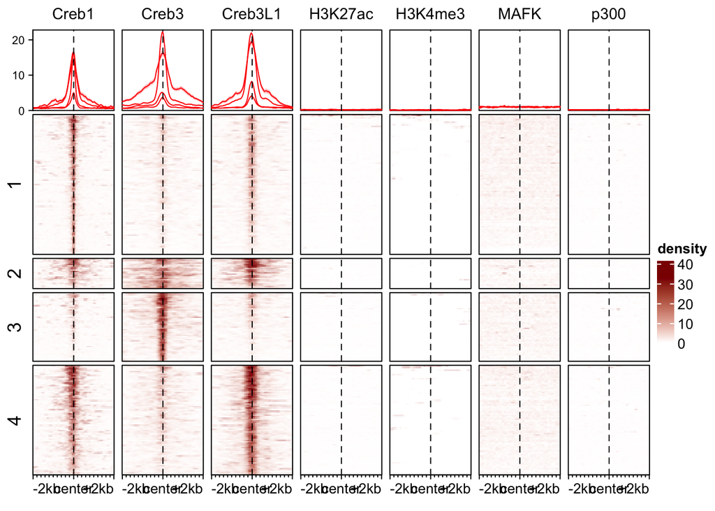

```r
plotEnrichedHeatmaps(ese_4, row_split=rowData(ese_4)$cluster,
                     colors=c("white","darkred"))
```

Figure 2

Adding colors:

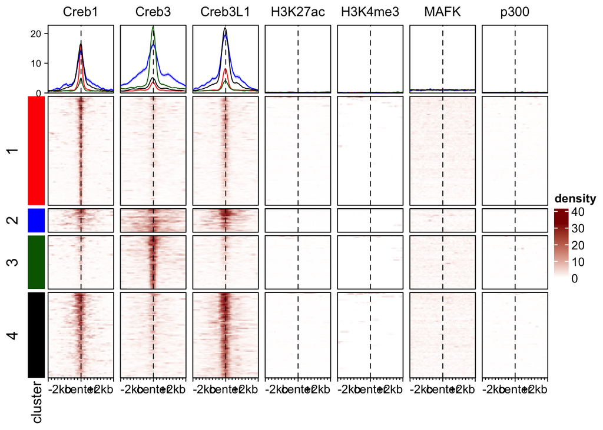

```r
mycolors <- c("1"="red", "2"="blue", "3"="darkgreen", "4"="black")
plotEnrichedHeatmaps(ese_4, row_split="cluster", mean_color=mycolors, colors=c("white","darkred"))
```

Figure 3

Trying different numbers of clusters:

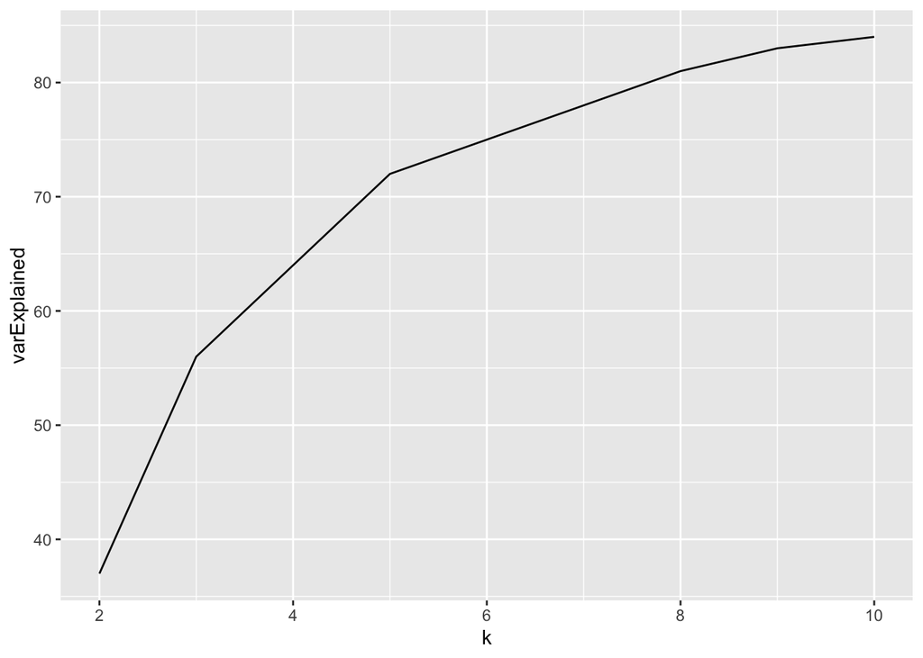

```r
cl2 <- clusterSignalMatrices(ese_4, k=2:10)
ggplot(cl2$varExplained, aes(k, varExplained)) + geom_line()
```

Figure 5

```r
ese_6 <- signal2Matrix(tracks, regions, extend=2000)
```

```
## Reading Creb1.bw
```

```
## Reading Creb3.bw
```

```
## Reading Creb3L1.bw
```

```
## Reading H3K27ac.bw
```

```
## Reading H3K4me3.bw
```

```
## Reading MAFK.bw
```

```
## Reading p300.bw
```

```r
set.seed(123)  # to ensure that it gives the same results everytime
cl_6 <- clusterSignalMatrices(ese_6, k=6)
```

```
##   ~75% of the variance explained by clusters
```

```r
table(cl_6)
```

```
## cl_6
##   1   2   3   4   5   6
## 521  98 328 545 542 235
```

```r
head(cl_6)
```

```
## [1] 5 4 1 1 1 4
## Levels: 1 2 3 4 5 6
```

```r
length(cl_6)
```

```
## [1] 2269
```

```r
nrow(ese_6)
```

```
## [1] 2269
```

```r
rowData(ese_6)$cluster <- cl_6
head(rowData(ese_6))
```

```
## DataFrame with 6 rows and 1 column
##                     cluster
##                    <factor>
## chr1:778487-779069        5
## chr1:904436-904985        4
## chr1:941785-942096        1
## chr1:943126-943501        1
## chr1:959088-959463        1
## chr1:961148-961904        4
```

Plotting the clusters:

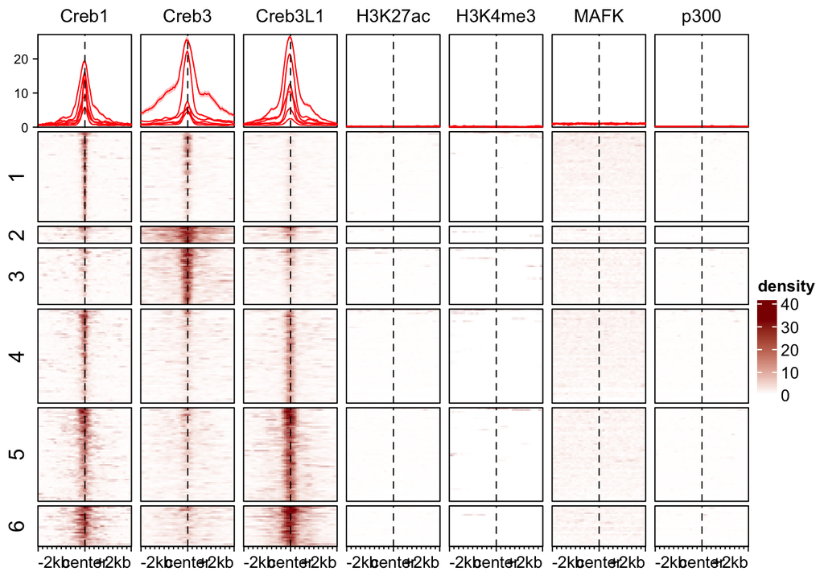

```r
plotEnrichedHeatmaps(ese_6, row_split=rowData(ese_6)$cluster,
                     colors=c("white","darkred"))
```

Figure 6

Since in two cates two clusters (2 & 3 and 5 & 6) are very similar and no new functional insights can be gained from them, we keep working with four clusters.

Plotting just the averages:

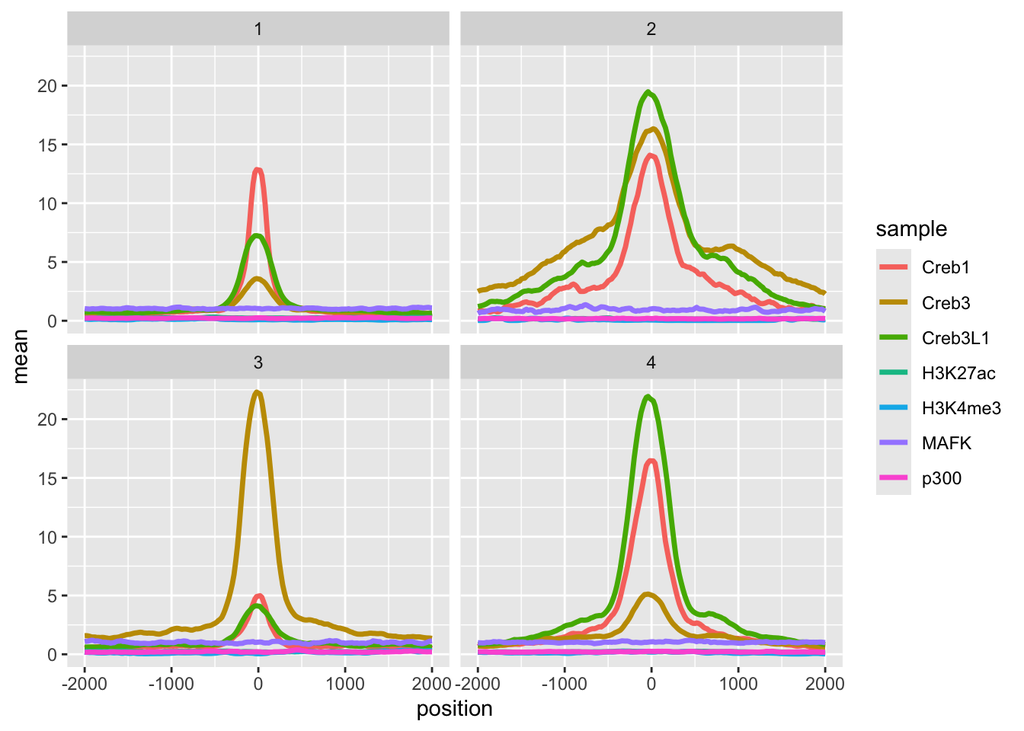

```r
d <- meltSignals(ese_4, splitBy=cl_4)
ggplot(d, aes(position, mean, colour=sample)) + geom_line(size=1.2) + facet_wrap(~split)
```

Figure 7

Clustering using relative signal instead:

```r
set.seed(123)
cl_4 <- clusterSignalMatrices(ese_4, k=4, scaleRows = TRUE)
```

```
##   ~74% of the variance explained by clusters
```

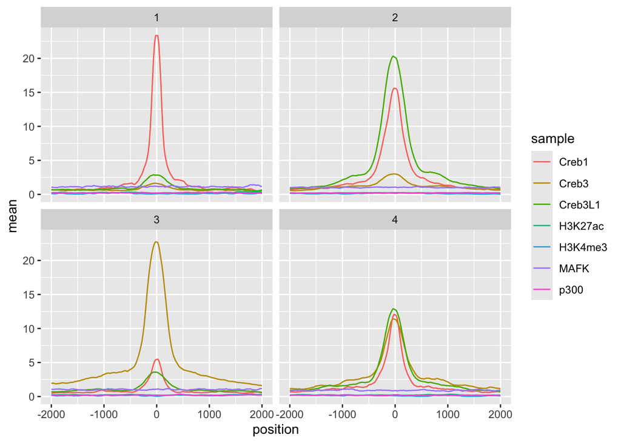

```r
d <- meltSignals(ese_4, splitBy=cl_4)
ggplot(d, aes(position, mean, colour=sample)) + geom_line() + facet_wrap(~split)
```

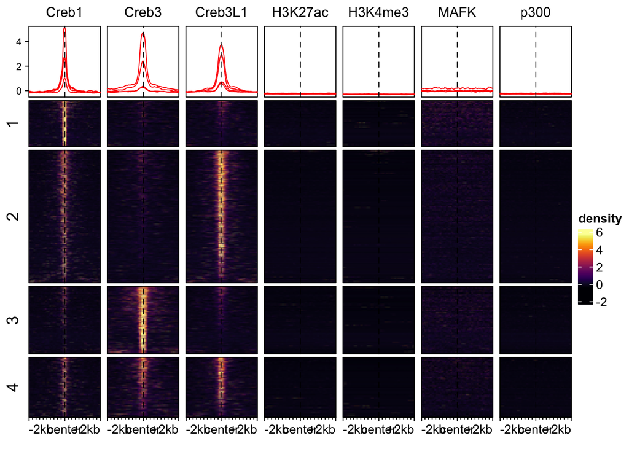

```r
plotEnrichedHeatmaps(ese_4, row_split = cl_4, scale_rows = "global")
```

Figure 8

## Enrichment analysis

Find what’s enriched in one cluster with respect to the others:

```r
# we first split the regions by cluster:
split_regions <- split(rowRanges(ese_4), rowData(ese_4)$cluster)
lengths(split_regions)
```

```
##   1   2   3   4
## 911 197 447 714
```

```r
res <- great(split_regions[["4"]], gene_sets="GO:BP", tss_source="mm10",
             background=regions, cores=2)
```

[output not shown]

[output not shown]

[output not shown]

[output not shown]

[output not shown]

[output not shown]

[output not shown]

[output not shown]

[output not shown]

[output not shown]

[output not shown]

[output not shown]

[output not shown]

[output not shown]

[output not shown]

[output not shown]

[output not shown]

[output not shown]

[output not shown]

[output not shown]

[output not shown]

[output not shown]

```r
bp <- getEnrichmentTables(res)
head(bp)
```

```
##           id                              description genome_fraction
## 1 GO:0099536                       synaptic signaling     0.049108745
## 2 GO:0006914                                autophagy     0.015515452
## 3 GO:0061919   process utilizing autophagic mechanism     0.015515452
## 4 GO:0031329 regulation of cellular catabolic process     0.012275111
## 5 GO:0022008                             neurogenesis     0.167369678
## 6 GO:0043648      dicarboxylic acid metabolic process     0.009261676
##   observed_region_hits fold_enrichment    p_value  p_adjust mean_tss_dist
## 1                   46        1.371445 0.02075430 0.8831744        212912
## 2                   18        1.698585 0.02270304 0.8831744        105234
## 3                   18        1.698585 0.02270304 0.8831744        105234
## 4                   15        1.789143 0.02397873 0.8831744        101308
## 5                  134        1.172215 0.02639209 0.8831744        296488
## 6                   12        1.897016 0.02784573 0.8831744         96326
##   observed_gene_hits gene_set_size fold_enrichment_hyper p_value_hyper
## 1                 13            15              1.314757    0.06796484
## 2                  9            12              1.137771    0.36974238
## 3                  9            12              1.137771    0.36974238
## 4                  7             7              1.517028    0.05288267
## 5                 39            58              1.020070    0.47337775
## 6                  4             5              1.213622    0.44548104
##   p_adjust_hyper
## 1      0.7868195
## 2      0.9032842
## 3      0.9032842
## 4      0.7308504
## 5      0.9452186
## 6      0.9032842
```

We plot the top Biological Processes:

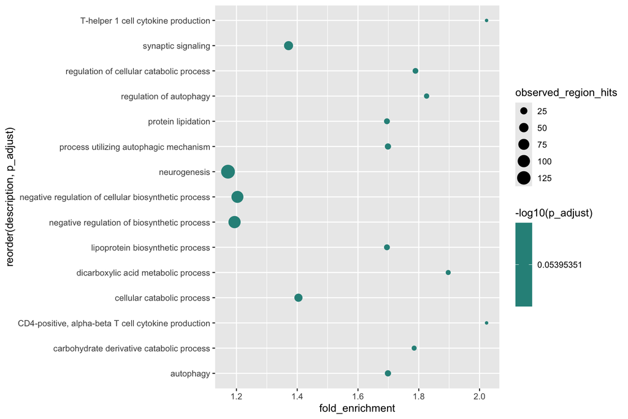

```r
ggplot(head(bp,15), aes(fold_enrichment, reorder(description, p_adjust),
                        size=observed_region_hits, color=-log10(p_adjust))) +
  geom_point() + scale_color_viridis_c()
```

Figure 9

The enrichment analysis of cluster 4, the second largest cluster containing 714 out of 2269 total regions, reveals several noteworthy patterns. Across all GO terms, the mean TSS distances are large (96,000–296,000 bp), indicating that CREB transcription factors in this cluster predominantly bind distal regulatory elements rather than promoter-proximal regions, making confident gene-to-peak assignment inherently difficult. Despite the cluster’s meaningful size providing reasonable statistical power, fold enrichments remain modest (1.17–2.05), and while raw p-values reach nominal significance (<0.05), none survive multiple testing correction, as confirmed by the uniformly similar color across all dots in the visualization (Figure 9, p_adjust ~0.88). Notably, neurogenesis shows the highest number of observed region hits (~125), yet its fold enrichment is only 1.17, meaning that while many regions are nominally linked to neurogenesis, this is barely above what would be expected by chance. Conversely, T-helper 1 cell cytokine production and CD4-positive T cell cytokine production display the highest fold enrichments (~2.0), but their very small dot sizes reveal that only very few regions actually overlap with these gene sets, making these enrichments unreliable. Overall, the combination of modest fold enrichments, large TSS distances, and non-significant adjusted p-values suggests that CREB binding sites in this cluster do not show strong or specific association with any particular biological process, possibly reflecting their role as broadly active distal regulatory elements controlling a diverse set of target genes.